# Analysis of Home Health Care Agency Quality and Patient Care Outcomes

Asta Adhira Anggono, Chang Gao, Kishaye Simone Williams

2023-08-07

Abstract: This paper presents a comprehensive analysis of home health care agencies (HHA) to understand the relationship between their services, ownership types, agency age, and patient care outcomes. A dataset containing information on multiple HHAs from 2015 to 2022 was analyzed. Data preprocessing involved removing missing values in the quality of patient care star rating. Subsequently, two data frames were created for further analysis: HHA_common, containing common and numerical variables, and HHA_PPR, focused on PPR-related analysis. Correlation analysis, regression, and independent t-tests were employed to investigate the research questions.

Introduction: Home health care agencies play a crucial role in providing care and support to patients in their homes. The quality of care delivered by these agencies directly impacts patient outcomes and overall health. This study aims to explore the factors influencing the quality of patient care in HHAs, including the correlation between service offerings, ownership types, agency age, and patient care outcomes. Our analysis and the way the report is generated is aimed to be reproducible in nature. This allows for the ABC Health Insurance to upload any data using the same format as the “HHA All Providers.csv” file so they reproduce the results that is current and applicable at that time. Outlined below is the process in which the report will be generated and how the data is analyzed.

The dataset was sourced from “HHA All Providers.csv,” and rows with missing values in the “Quality.of.Patient.Care.Star.Rating” column were removed. This step ensured the analysis focused on complete and reliable data. Two data frames, HHA_common and HHA_PPR, were created. HHA_common contained common and numerical variables, while HHA_PPR focused on PPR-related analysis. Missing values in HHA_common and HHA_PPR were imputed using the Multiple Imputation by Chained Equations (MICE) method. This ensured a robust and complete dataset for further analysis. The latter was further filtered for data from 2019 to 2022 and cases with valid DTC observed rates. The correlation between the “Quality.of.Patient.Care.Star.Rating” and other numerical variables in HHA_common and HHA_PPR was explored using correlation heatmaps. The analysis shed light on potential relationships between service offerings and patient care outcomes.

## Specific Questions

This research aims to analyze home health care agencies (HHAs) and investigate various factors influencing the quality of patient care. The research questions explore the relationships between PPR rates, specific services offered, HHA ownership types, agency age, and patient care outcomes.

### Q1

#### Question

What variables are important in influencing the quality rating score?

#### Answer

The first research question seeks to identify the variables that significantly influence the quality rating score in home health care agencies (HHAs). To achieve this, a correlation heatmap is generated using the HHA_common data frame. The numerical variables, excluding the “Quality.of.Patient.Care.Star.Rating” column, are selected and analyzed for their correlation with the quality rating. This analysis aims to uncover key factors that play a crucial role in determining the overall quality of patient care in HHAs. By understanding the important variables that impact the quality rating, healthcare administrators and policymakers can focus their efforts on improving specific aspects of care delivery to enhance patient outcomes and satisfaction. The analysis involves computing the correlation matrix between the “Quality.of.Patient.Care.Star.Rating” and other numerical variables in HHA_common. The correlation heatmap provides a visual representation of the relationships between these variables, where stronger correlations are indicated by distinct color patterns. Through this analysis, the study aims to pinpoint variables that positively or negatively correlate with the quality rating. By identifying these influential factors, HHAs can prioritize resources, develop targeted quality improvement initiatives, and align their practices with evidence-based strategies to achieve higher quality ratings and improved patient care outcomes.

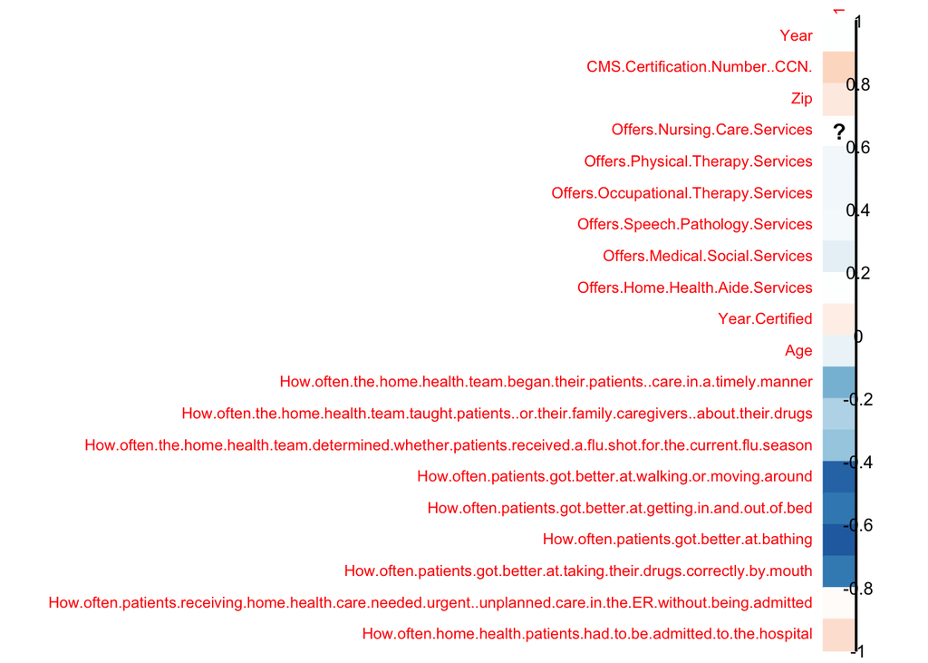

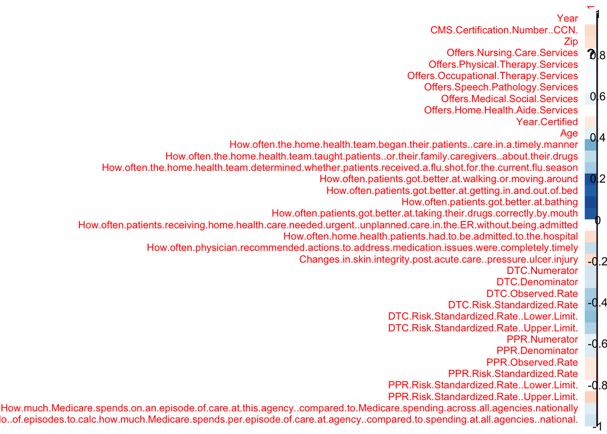

On the other hand, the heatmap also highlights the bottom three variables with weak correlations to the quality rating in the PPR data: “PPR Risk Standardized Rate Upper Limit,” “How much Medicare spends on an episode of care at this agency compared to Medicare spending across all agencies nationally,” and “How much Medicare spends per episode of care at the agency compared to spending at all agencies nationally.” These factors may warrant further investigation to understand their impact on patient outcomes and identify potential areas for improvement. Overall, these findings offer valuable insights to stakeholders, enabling them to focus their efforts on crucial aspects that contribute to higher quality patient care and better network management within the home health care setting.

Recommendations:

### Q2

#### Question

How do the PPR (Preventable Potential Readmission) and DTC rate and the performance of the two figures correlate with the rating of an institution?

#### Answer

##### DTC (Discharge to Community)

```
## [1] "Correlation coefficient: 0.297490447922436"
```

```
## Analysis of Variance Table
##
## Response: Quality.of.Patient.Care.Star.Rating
##                                   Df  Sum Sq Mean Sq F value    Pr(>F)
## DTC.Performance.Categorization     2  2612.3 1306.14  1471.7 < 2.2e-16 ***
## Residuals                      31374 27844.8    0.89
## ---
## Signif. codes:  0 '***' 0.001 '**' 0.01 '*' 0.05 '.' 0.1 ' ' 1
```

##### PPR (Preventable Potential Readmission)

```
## [1] "Correlation coefficient: -0.0970284661453812"
```

```
## Analysis of Variance Table
##
## Response: Quality.of.Patient.Care.Star.Rating
##                                   Df  Sum Sq Mean Sq F value    Pr(>F)
## PPR.Performance.Categorization     4  1256.4 314.111  337.47 < 2.2e-16 ***
## Residuals                      31372 29200.6   0.931
## ---
## Signif. codes:  0 '***' 0.001 '**' 0.01 '*' 0.05 '.' 0.1 ' ' 1
```

##### Summary

The analysis examines the correlation between the PPR (Preventable Potential Readmission) and DTC (Discharge to Community) rates and the quality rating of home health care agencies. The correlation coefficients show a weak positive correlation between DTC performance categorization and the quality rating score (correlation coefficient: 0.2974904). This suggests that agencies with higher DTC performance categorization tend to have slightly higher quality ratings. On the other hand, the correlation between PPR performance categorization and the quality rating score is weak and negative (correlation coefficient: -0.0970285). It indicates that agencies with higher PPR performance categorization may have slightly lower quality ratings. These results provide insights into the relationship between preventable readmissions and discharge practices and overall care quality. Agencies can use this information to tailor interventions and improve care coordination, ultimately enhancing the patient experience and health outcomes.

Recommendations:

ABC Health Insurance should focus on improving Discharge to Community (DTC) rates in home health care agencies to enhance overall care quality and patient outcomes. A weak positive correlation between DTC performance categorization and quality ratings suggests that agencies with higher DTC rates tend to have slightly higher quality ratings. To achieve this ABC Health Insurance should support agencies in enhancing discharge planning by encouraging them to invest in comprehensive discharge planning and care coordination processes. This includes ensuring smooth transitions from hospital to home care, effective communication with other healthcare providers, and patient education on managing their conditions after discharge. ABC can also collaborate with agencies to adopt evidence-based interventions aimed at reducing preventable readmissions. These interventions may include post-discharge follow-ups, medication reconciliation, and patient education on managing chronic conditions.

### Q3

#### Question

Do home health care agencies offering a comprehensive range of services, including physical therapy, occupational therapy, and speech pathology, tend to have higher quality ratings? How does the variation in services offered impact the overall quality of care and network management?

#### Answer

##### Physical Therapy Service

```
##
##  Welch Two Sample t-test
##
## data:  physical_y$Quality.of.Patient.Care.Star.Rating and physical_n$Quality.of.Patient.Care.Star.Rating
## t = 11.507, df = 296.47, p-value < 2.2e-16
## alternative hypothesis: true difference in means is not equal to 0
## 95 percent confidence interval:
##  0.5250915 0.7417668
## sample estimates:
## mean of x mean of y
##  3.257158  2.623729
```

##### Occupational Therapy Service

```
##
##  Welch Two Sample t-test
##
## data:  occupational_y$Quality.of.Patient.Care.Star.Rating and occupational_n$Quality.of.Patient.Care.Star.Rating
## t = 11.976, df = 2843.4, p-value < 2.2e-16
## alternative hypothesis: true difference in means is not equal to 0
## 95 percent confidence interval:
##  0.1892946 0.2634122
## sample estimates:
## mean of x mean of y
##  3.263096  3.036742
```

##### Speech Pathology Service

```
##
##  Welch Two Sample t-test
##
## data:  speech_y$Quality.of.Patient.Care.Star.Rating and speech_n$Quality.of.Patient.Care.Star.Rating
## t = 9.5762, df = 6165.1, p-value < 2.2e-16
## alternative hypothesis: true difference in means is not equal to 0
## 95 percent confidence interval:
##  0.1046509 0.1585257
## sample estimates:
## mean of x mean of y
##  3.264564  3.132976
```

##### Medical Social Service

```
##
##  Welch Two Sample t-test
##
## data:  medical_y$Quality.of.Patient.Care.Star.Rating and medical_n$Quality.of.Patient.Care.Star.Rating
## t = 23.558, df = 10476, p-value < 2.2e-16
## alternative hypothesis: true difference in means is not equal to 0
## 95 percent confidence interval:
##  0.2400211 0.2835892
## sample estimates:
## mean of x mean of y
##  3.285615  3.023810
```

##### Home Health Aid Service

```
##
##  Welch Two Sample t-test
##
## data:  homeaid_y$Quality.of.Patient.Care.Star.Rating and homeaid_n$Quality.of.Patient.Care.Star.Rating
## t = 1.6703, df = 3144.5, p-value = 0.09496
## alternative hypothesis: true difference in means is not equal to 0
## 95 percent confidence interval:
##  -0.005736625  0.071723530
## sample estimates:
## mean of x mean of y
##  3.255858  3.222865
```

##### Summary

Recommendations:

### Q4

#### Question

How does the service quality rating score vary across different types of HHA ownership and how has this been changing over the years?

#### Answer

The fourth research question examines how the quality rating score varies across different types of HHA ownership and how this variation has changed over the years. The analysis utilizes the HHA_common data frame to group agencies by their ownership types and calculate summary statistics such as mean, median, and standard deviation of the quality rating for each ownership type in different years. The study aims to identify any patterns or trends in the quality ratings based on the agency’s ownership structure. Understanding how ownership types impact patient care quality is essential for assessing the effectiveness of different management models and identifying areas for improvement in home health care services. The analysis groups data by both ownership type and year to calculate the mean, median, and standard deviation of the “Quality.of.Patient.Care.Star.Rating” for each combination. These summary statistics help visualize the trends and variations in quality ratings over time and across different ownership types. The results are presented through line plots and box plots to illustrate the changes in quality ratings for each ownership type over the years. The findings from this analysis can provide valuable insights into the performance of HHAs under different ownership structures and inform stakeholders about the impact of ownership models on patient care outcomes. Policymakers and healthcare administrators can use these insights to develop targeted strategies to support and regulate home health care agencies effectively, leading to more consistent and high-quality patient care.

```
## # A tibble: 25 × 5
## # Groups:   Type.of.Ownership [4]
##    Type.of.Ownership  Year  Mean Median    SD
##    <chr>             <int> <dbl>  <dbl> <dbl>
##  1 Non-profit         2015  3.43    3.5 0.741
##  2 Non-profit         2016  3.33    3.5 0.721
##  3 Non-profit         2017  3.29    3.5 0.739
##  4 Non-profit         2018  3.23    3   0.752
##  5 Non-profit         2019  3.24    3   0.789
##  6 Non-profit         2020  3.26    3.5 0.802
##  7 Non-profit         2021  3.26    3.5 0.802
##  8 Non-profit         2022  3.22    3   0.800
##  9 Others             2015  3.36    3.5 0.693
## 10 Proprietary        2015  3.24    3   0.812
## # ℹ 15 more rows
```

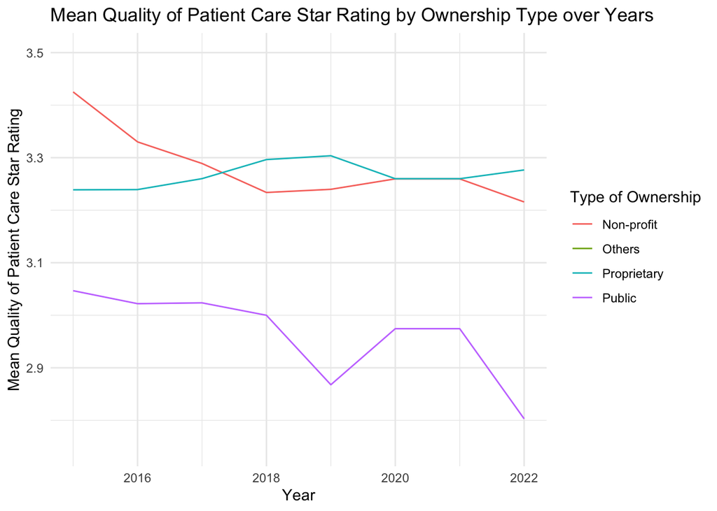

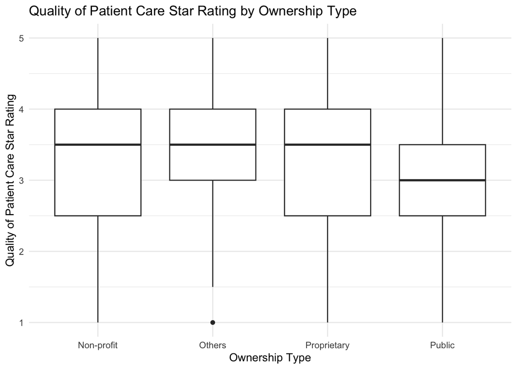

The analysis examines the variation in quality rating scores across different types of home health agency ownership and how this variation has changed over the years. The summary table provides insights into the mean, median, and standard deviation of quality ratings for each ownership type in various years (2015-2022). (Potential Recommendation for future work ) While the summary table presents valuable information on the central tendency and spread of quality ratings, additional statistical analysis or data visualization can help identify trends and patterns. For instance, time series plots or box plots may reveal how quality ratings have evolved over the years for different ownership types. Understanding the relationship between ownership type and care quality can assist policymakers and stakeholders in developing targeted interventions and regulatory policies to enhance care outcomes in specific ownership categories.

Recommendations:

Based on the analysis of how the quality rating score varies across different types of home health agency (HHA) ownership and how this variation has changed over the years, ABC Health Insurance can consider the following recommendations: First, ABC can establish performance benchmarks for each ownership type based on the mean and median quality ratings over the years. By setting clear benchmarks, ABC Health Insurance can assess the performance of HHAs relative to their ownership type and identify agencies that excel in providing high-quality care. This can also serve as a basis for recognizing and rewarding top-performing agencies. Moreover, ABC can support research initiatives focused on understanding how ownership types influence patient care quality in the home health care sector. Collaborate with academic institutions and healthcare research organizations to conduct rigorous studies that can contribute to evidence-based policymaking and best practices in the industry. ABC should also work with regulatory authorities to ensure that policies and regulations align with the varying needs and characteristics of different ownership types. This alignment can create an enabling environment for HHAs to thrive and continuously improve care quality.

### Q5

#### Question

Is there a correlation between the age of home healthcare agencies and the quality of patient care they provide? How do the agency’s years of certification contribute to this relationship?

#### Answer

The fifth research question investigates the correlation between the age of home healthcare agencies and the quality of patient care they provide. The analysis calculates the correlation coefficient and assesses its significance using the cor.test function. By understanding the relationship between agency age and the “Quality.of.Patient.Care.Star.Rating,” the study aims to determine whether the age of an agency influences the quality of care delivered to patients. This analysis is crucial for identifying potential trends or patterns related to the longevity of agencies and their care performance. The findings can help healthcare administrators and policymakers make informed decisions about the accreditation and certification processes for new agencies and guide continuous quality improvement efforts for established ones. The analysis calculates the correlation coefficient between the “Quality.of.Patient.Care.Star.Rating” and the age of home healthcare agencies using the cor function. The significance of this correlation is assessed with the cor.test function. The obtained correlation coefficient and p-value provide insights into the strength and statistical significance of the relationship. This information can help identify whether there is a meaningful association between agency age and the quality rating. Understanding this relationship can assist in designing strategies to ensure that new agencies meet quality standards and that older agencies continue to deliver high-quality care. Policymakers can utilize the findings to develop policies and guidelines that support both new and established agencies in maintaining and improving the quality of patient care in home health care settings.

```
## [1] "Correlation coefficient: 0.075985991632685"
```

```
## [1] "P-value: 4.25252077620996e-89"
```

The analysis explores the correlation between the age of home healthcare agencies and the quality of patient care they provide. The correlation coefficient of 0.075986 suggests a weak positive correlation between agency age and quality rating. The low correlation indicates that the age of an agency may have limited influence on care quality. However, the p-value is highly significant (p-value < 0.001), indicating that the correlation is statistically significant despite being weak. These findings imply that while agency age might have some impact on care quality, it is not a strong predictor. Other factors, such as the agency’s management practices, staffing, and ongoing quality improvement initiatives, may play a more substantial role in determining care quality. Healthcare administrators can use this insight to focus on these critical factors rather than relying solely on the agency’s age when evaluating and improving care quality.

Recommendations:

Based on the analysis of the correlation between the age of home healthcare agencies and the quality of patient care they provide, ABC can first implement a system for ongoing monitoring and evaluation of care quality in all agencies, with a focus on key performance indicators related to patient outcomes, safety, and satisfaction. This monitoring can help identify agencies that may require additional support and interventions, regardless of their age. They can also facilitate benchmarking exercises and platforms for agencies to share best practices. Encourage collaboration and knowledge exchange among agencies, regardless of their age, to foster innovation and improvement in care delivery. Especially for new agencies, it is good to offer targeted support and guidance during their initial years of operation. This support can include mentorship programs, technical assistance, or even access to resources that will aid in achieving and maintaining quality standards. It is also a good idea to collaborate with accreditation bodies to ensure that the accreditation process considers both the age of the agency and other critical quality indicators. This can lead to a more comprehensive assessment of agency performance.

### Q6

#### Question

How does the practice of “How frequently do home health care agencies assess and address the risk of falling among their patients” impact patient outcomes and overall quality of care?

#### Answer

The sixth research question explores the impact of the frequency of assessing and addressing the risk of falling among patients on patient outcomes and the overall quality of care in home health care agencies. The analysis calculates the correlation coefficient and p-value to determine the strength and significance of the relationship between the frequency of risk assessment and the “Quality.of.Patient.Care.Star.Rating.” This study aims to identify whether more frequent assessments of fall risk are associated with better patient outcomes and higher care quality. Understanding this relationship can assist in developing evidence-based fall prevention practices and interventions to enhance patient safety and care quality in home health care settings. The analysis calculates the correlation coefficient between the “Quality.of.Patient.Care.Star.Rating” and the frequency of assessing and addressing the risk of falling among patients using the cor function. The statistical significance of this relationship is assessed with the cor.test function, providing insights into whether the correlation is meaningful. The results from this analysis can inform healthcare providers and administrators about the impact of fall prevention practices on patient care quality. Understanding this relationship can guide the development and implementation of fall prevention programs and interventions in home health care agencies, ultimately leading to improved patient outcomes and enhanced overall care quality. Policymakers can use these insights to establish guidelines and regulations focused on fall prevention in home health care settings, promoting safer care environments and better patient experiences.

```
## [1] "Correlation coefficient: 0.143291434597273"
```

```
## [1] "P-value: 1.24939141397678e-241"
```

The analysis investigates the impact of how frequently home health care agencies assess and address the risk of falling among their patients on patient outcomes and overall care quality. The correlation coefficient of 0.1432914 indicates a weak positive correlation between the frequency of risk assessment and addressing falls and the quality rating score. Despite the weak correlation, the highly significant p-value (p-value < 0.001) indicates that this relationship is statistically significant. While the correlation suggests that more frequent risk assessment and addressing falls may lead to better quality ratings, it is essential to consider other factors and conduct further analysis to identify potential confounding variables. Healthcare administrators can utilize this insight to emphasize fall risk assessment and prevention strategies, which may contribute to improved patient safety and care quality.

Recommendations:

Based on the analysis of the impact of the frequency of assessing and addressing the risk of falling among patients on patient outcomes and the overall quality of care in home health care agencies, ABC can provide resources for fall prevention initiatives. Given the significance of fall prevention in enhancing patient safety and care quality, ABC can allocate resources to support home health care agencies’ fall prevention initiatives. This could include funding for training, education, and technology adoption related to fall risk assessments and interventions. ABC can consider offering performance-based contracts to home health care agencies, where reimbursement is tied to specific quality metrics and patient outcomes. This approach aligns the financial incentives of the agencies with ABC’s goals of providing high-quality, cost-effective care.

### Independent Analysis 1

#### Question

What are the top-five states with the most HHAs and how have this been changing over the years?

#### Answer

The first independent analysis aims to identify the top five states with the most home health agencies (HHAs) and explore how this distribution has changed over the years. To achieve this, the analysis uses the HHA data frame and subsets the data for each year of interest. The data for the years 2015 and 2016 are combined into the HHA_15_16 data frame, and the analysis is performed for each year independently. The study aggregates the number of HHAs for each state and year, and then selects the top five states based on the highest counts. Through this analysis, the research seeks to understand the geographic distribution of HHAs and how it has evolved over the years, providing insights for healthcare administrators and policymakers to focus their efforts in regions with the highest demand for home health care services. The analysis starts by subsetting the data for each year of interest, creating data frames for 2015-2016, 2017-2018, 2019, 2020, and 2021-2022. For each year’s data frame, the count of HHAs is calculated for each state. The states with the highest counts are identified and visualized using a bar plot, showing the top five states for each year. The bar plot displays the change in the top five states over time, allowing stakeholders to observe shifts in the distribution of HHAs across states. This information can be valuable for resource allocation and strategic planning to address the evolving healthcare needs of different regions.

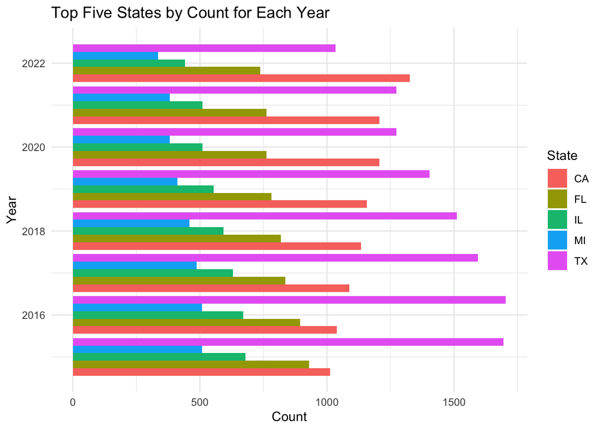

Additionally, it is interesting to note that California takes the top spot in 2022, surpassing Texas, which ranked second in that year. This shift in ranking may reflect changing trends in home health care utilization or the emergence of new opportunities in California.Overall, this analysis provides valuable information for policymakers, healthcare administrators, and investors, allowing them to understand the geographical distribution of HHAs and identify potential areas for expansion or resource allocation in the home health care industry.

Recommendations:

ABC company can strategically expand its network of home health care providers in states with consistently high numbers of HHAs, such as Texas, California, and Florida. By establishing strong partnerships with top-performing HHAs in these states, ABC can ensure access to high-quality care for its members and potentially negotiate favorable reimbursement rates. ABC can also allocate resources, such as marketing efforts and provider support, to focus on these states to capture a larger share of the home health care market. To attract and retain members in states with high HHA counts, ABC can engage in regional outreach and education initiatives. Educating potential members about the benefits of home health care and the availability of quality providers in their area can enhance enrollment rates. Moreover, partnering with state and local healthcare authorities can provide ABC with valuable information on regional healthcare trends and regulatory changes that may impact home health care services. Such collaboration can help ABC adapt its offerings and policies to align with regional needs.

### Independent Analysis 2

#### Question

For different types of ownership of HHAs, what are their respective specializations?

#### Answer

##### Results from 2015-2016

```
## # A tibble: 10 × 5
##    Type.of.Ownership mean_value median_value Performance_Measure Column_Name
##  * <chr>                  <dbl>        <dbl> <chr>               <chr>
##  1 Others                  3.36          3.5 Mean                Quality.of.Pat…
##  2 Others                 92.2          94   Mean                How.often.the.…
##  3 Non-profit             95.0          97.5 Mean                How.often.the.…
##  4 Non-profit             99.1          99.7 Mean                How.often.the.…
##  5 Others                 61.9          62.8 Mean                How.often.pati…
##  6 Others                 97.9          99.2 Mean                How.often.the.…
##  7 Non-profit             78.3          82.3 Mean                How.often.the.…
##  8 Others                 66.5          67.4 Mean                How.often.pati…
##  9 Non-profit             98.9          99.5 Mean                How.often.the.…
## 10 Non-profit             98.5          99.4 Mean                How.often.the.…
```

```
## # A tibble: 10 × 5
##    Type.of.Ownership mean_value median_value Performance_Measure Column_Name
##  * <chr>                  <dbl>        <dbl> <chr>               <chr>
##  1 Non-profit              3.35          3.5 Median              Quality.of.Pat…
##  2 Non-profit             92.1          94   Median              How.often.the.…
##  3 Non-profit             95.0          97.5 Median              How.often.the.…
##  4 Non-profit             99.1          99.7 Median              How.often.the.…
##  5 Others                 61.9          62.8 Median              How.often.pati…
##  6 Others                 97.9          99.2 Median              How.often.the.…
##  7 Non-profit             78.3          82.3 Median              How.often.the.…
##  8 Others                 66.5          67.4 Median              How.often.pati…
##  9 Proprietary            98.7          99.6 Median              How.often.the.…
## 10 Others                 98.4          99.5 Median              How.often.the.…
```

##### Results from 2021-2022

```
## # A tibble: 7 × 5
##   Type.of.Ownership mean_value median_value Performance_Measure Column_Name
## * <chr>                  <dbl>        <dbl> <chr>               <chr>
## 1 Proprietary            3.27          3.5  Mean                Quality.of.Pati…
## 2 Proprietary           94.6          97.9  Mean                How.often.the.h…
## 3 Public                96.7          98.7  Mean                How.often.the.h…
## 4 Non-profit            78.1          79.3  Mean                How.often.patie…
## 5 Non-profit            80.2          81.5  Mean                How.often.patie…
## 6 Non-profit            94.0          96.8  Mean                How.often.physi…
## 7 Public                 0.365         0.18 Mean                Changes.in.skin…
```

```
## # A tibble: 7 × 5
##   Type.of.Ownership mean_value median_value Performance_Measure Column_Name
## * <chr>                  <dbl>        <dbl> <chr>               <chr>
## 1 Proprietary            3.27          3.5  Median              Quality.of.Pati…
## 2 Proprietary           94.6          97.9  Median              How.often.the.h…
## 3 Public                96.7          98.7  Median              How.often.the.h…
## 4 Non-profit            78.1          79.3  Median              How.often.patie…
## 5 Non-profit            80.2          81.5  Median              How.often.patie…
## 6 Proprietary           91.7          97.2  Median              How.often.physi…
## 7 Non-profit             0.288         0.19 Median              Changes.in.skin…
```

##### Summary

The second independent analysis investigates the specialization areas of home health care agencies based on their types of ownership. To accomplish this, the analysis uses data for the years 2015 and 2021-2022, separately. The focus is on the columns representing various performance measures related to patient care quality. By comparing the mean and median performance of each type of ownership for each performance measure, the study aims to identify the types of ownership that excel in different care aspects. This analysis can help healthcare policymakers and administrators understand the strengths and weaknesses of different ownership models and guide decisions regarding ownership structures and care quality improvement initiatives. The analysis is conducted separately for the years 2015 and 2021-2022. For each year’s data, the mean and median values of performance measures are calculated for each type of ownership. The types of ownership with the highest mean and median values for each performance measure are identified. This process is performed for various performance measures, allowing for a comprehensive comparison of ownership types’ specializations. The results are presented in summary tables, providing insights into the areas in which each type of ownership excels. Healthcare administrators and policymakers can utilize this information to support and incentivize ownership structures that align with specific performance goals, fostering the delivery of high-quality care.

Recommendations:

### Independent Analysis 3

#### Question

How have influencing factors been changing from 2015 to 2022? A good way to look into this question might be to compare these factors from 2015 to 2022

#### Answer

##### Results from 2015-2016

```
##
## Call:
## lm(formula = Quality.of.Patient.Care.Star.Rating ~ How.often.patients.got.better.at.bathing +
##     How.often.patients.had.less.pain.when.moving.around + How.often.the.home.health.team.determined.whether.patients.received.a.flu.shot.for.the.current.flu.season +
##     How.often.the.home.health.team.began.their.patients..care.in.a.timely.manner +
##     How.often.patients.got.better.at.getting.in.and.out.of.bed +
##     How.often.home.health.patients.had.to.be.admitted.to.the.hospital +
##     How.often.the.home.health.team.taught.patients..or.their.family.caregivers..about.their.drugs +
##     How.often.patients.got.better.at.walking.or.moving.around +
##     How.often.patients..breathing.improved + How.often.home.health.patients..who.have.had.a.recent.hospital.stay..received.care.in.the.hospital.emergency.room.without.being.re.admitted.to.the.hospital +
##     How.often.home.health.patients..who.have.had.a.recent.hospital.stay..had.to.be.re.admitted.to.the.hospital +
##     Type.of.Ownership + With.diabetes..how.often.the.home.health.team.got.doctor.s.orders..gave.foot.care..and.taught.patients.about.foot.care +
##     How.often.the.home.health.team.checked.patients.for.pain +
##     How.often.the.home.health.team.checked.patients.for.depression +
##     Offers.Home.Health.Aide.Services + How.often.patients.receiving.home.health.care.needed.urgent..unplanned.care.in.the.ER.without.being.admitted +
##     How.often.the.home.health.team.took.doctor.ordered.action.to.prevent.pressure.sores..bed.sores. +
##     How.often.the.home.health.team.made.sure.that.their.patients.have.received.a.pneumococcal.vaccine..pneumonia.shot.. +
##     How.often.the.home.health.team.checked.patients.for.the.risk.of.developing.pressure.sores..bed.sores. +
##     How.often.patients..wounds.improved.or.healed.after.an.operation +
##     Offers.Physical.Therapy.Services + How.often.the.home.health.team.checked.patients..risk.of.falling +
##     Year.Certified, data = HHA_15_16)
##
## Residuals:
##      Min       1Q   Median       3Q      Max
## -1.23617 -0.21242 -0.01487  0.18983  1.83206
##
## Coefficients: (1 not defined because of singularities)
##                                                                                                                                                                                   Estimate
## (Intercept)                                                                                                                                                                     -3.7685266
## How.often.patients.got.better.at.bathing                                                                                                                                         0.0109965
## How.often.patients.had.less.pain.when.moving.around                                                                                                                              0.0102737
## How.often.the.home.health.team.determined.whether.patients.received.a.flu.shot.for.the.current.flu.season                                                                        0.0085430
## How.often.the.home.health.team.began.their.patients..care.in.a.timely.manner                                                                                                     0.0190587
## How.often.patients.got.better.at.getting.in.and.out.of.bed                                                                                                                       0.0097459
## How.often.home.health.patients.had.to.be.admitted.to.the.hospital                                                                                                               -0.0289683
## How.often.the.home.health.team.taught.patients..or.their.family.caregivers..about.their.drugs                                                                                    0.0109361
## How.often.patients.got.better.at.walking.or.moving.around                                                                                                                        0.0107626
## How.often.patients..breathing.improved                                                                                                                                           0.0060810
## How.often.home.health.patients..who.have.had.a.recent.hospital.stay..received.care.in.the.hospital.emergency.room.without.being.re.admitted.to.the.hospitalBetter than expected  0.0693344
## How.often.home.health.patients..who.have.had.a.recent.hospital.stay..received.care.in.the.hospital.emergency.room.without.being.re.admitted.to.the.hospitalSame as expected     -0.0145895
```

[output cut: 138 more lines]

```
## Offers.Home.Health.Aide.Services                                                                                                                                                ***
## How.often.patients.receiving.home.health.care.needed.urgent..unplanned.care.in.the.ER.without.being.admitted                                                                    ***
## How.often.the.home.health.team.took.doctor.ordered.action.to.prevent.pressure.sores..bed.sores.                                                                                 ***
## How.often.the.home.health.team.made.sure.that.their.patients.have.received.a.pneumococcal.vaccine..pneumonia.shot..                                                             ***
## How.often.the.home.health.team.checked.patients.for.the.risk.of.developing.pressure.sores..bed.sores.                                                                           ***
## How.often.patients..wounds.improved.or.healed.after.an.operation                                                                                                                **
## Offers.Physical.Therapy.Services                                                                                                                                                *
## How.often.the.home.health.team.checked.patients..risk.of.falling                                                                                                                .
## Year.Certified
## ---
## Signif. codes:  0 '***' 0.001 '**' 0.01 '*' 0.05 '.' 0.1 ' ' 1
##
## Residual standard error: 0.3083 on 18593 degrees of freedom
## Multiple R-squared:  0.8616, Adjusted R-squared:  0.8614
## F-statistic:  3991 on 29 and 18593 DF,  p-value: < 2.2e-16
```

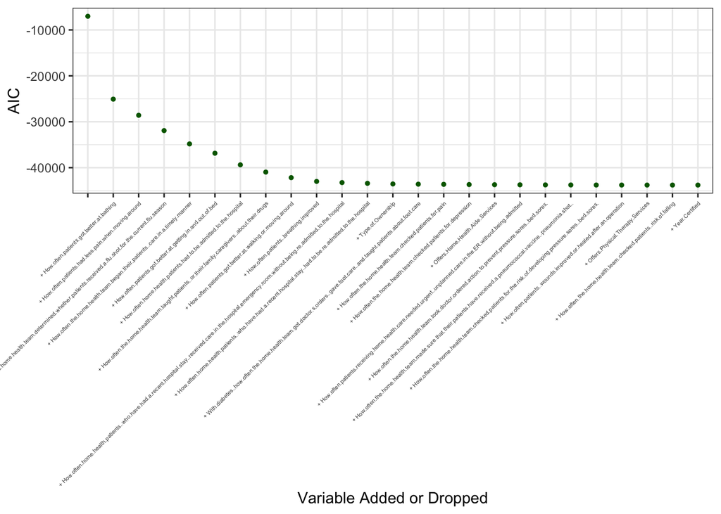

##### Results from 2021-2022

```
##
## Call:
## lm(formula = Quality.of.Patient.Care.Star.Rating ~ How.often.patients.got.better.at.bathing +
##     How.often.patients.got.better.at.taking.their.drugs.correctly.by.mouth +
##     How.often.the.home.health.team.began.their.patients..care.in.a.timely.manner +
##     How.often.patients.got.better.at.walking.or.moving.around +
##     How.often.home.health.patients.had.to.be.admitted.to.the.hospital +
##     How.often.patients.got.better.at.getting.in.and.out.of.bed +
##     PPR.Performance.Categorization + DTC.Performance.Categorization +
##     Type.of.Ownership + Changes.in.skin.integrity.post.acute.care..pressure.ulcer.injury +
##     PPR.Denominator + DTC.Numerator + DTC.Risk.Standardized.Rate..Lower.Limit. +
##     DTC.Observed.Rate + How.often.the.home.health.team.taught.patients..or.their.family.caregivers..about.their.drugs +
##     How.much.Medicare.spends.on.an.episode.of.care.at.this.agency..compared.to.Medicare.spending.across.all.agencies.nationally +
##     How.often.the.home.health.team.determined.whether.patients.received.a.flu.shot.for.the.current.flu.season +
##     PPR.Numerator + Offers.Home.Health.Aide.Services + How.often.physician.recommended.actions.to.address.medication.issues.were.completely.timely +
##     Offers.Occupational.Therapy.Services + DTC.Risk.Standardized.Rate +
##     Offers.Physical.Therapy.Services + DTC.Denominator + PPR.Risk.Standardized.Rate +
##     PPR.Risk.Standardized.Rate..Upper.Limit. + PPR.Risk.Standardized.Rate..Lower.Limit.,
##     data = HHA_21_22)
##
## Residuals:
##      Min       1Q   Median       3Q      Max
## -1.35600 -0.28380 -0.01942  0.26592  3.13532
##
## Coefficients:
##                                                                                                                               Estimate
## (Intercept)                                                                                                                 -3.103e+00
## How.often.patients.got.better.at.bathing                                                                                     1.501e-02
## How.often.patients.got.better.at.taking.their.drugs.correctly.by.mouth                                                       1.766e-02
## How.often.the.home.health.team.began.their.patients..care.in.a.timely.manner                                                 2.029e-02
## How.often.patients.got.better.at.walking.or.moving.around                                                                    1.558e-02
## How.often.home.health.patients.had.to.be.admitted.to.the.hospital                                                           -3.017e-02
## How.often.patients.got.better.at.getting.in.and.out.of.bed                                                                   1.178e-02
## PPR.Performance.CategorizationBetter Than National Rate                                                                     -3.627e-01
## PPR.Performance.CategorizationNot Available                                                                                 -1.412e-01
## PPR.Performance.CategorizationSame As National Rate                                                                         -3.017e-01
## PPR.Performance.CategorizationWorse Than National Rate                                                                      -2.538e-01
## DTC.Performance.CategorizationBetter Than National Rate                                                                      1.514e-01
## DTC.Performance.CategorizationNot Available                                                                                  2.717e-02
## DTC.Performance.CategorizationSame As National Rate                                                                          1.342e-01
```

[output cut: 156 more lines]

```
## Offers.Home.Health.Aide.Services                                                                                            **
## How.often.physician.recommended.actions.to.address.medication.issues.were.completely.timely                                 **
## Offers.Occupational.Therapy.Services                                                                                        ***
## DTC.Risk.Standardized.Rate                                                                                                  *
## Offers.Physical.Therapy.Services                                                                                            **
## DTC.Denominator                                                                                                             *
## PPR.Risk.Standardized.Rate                                                                                                  **
## PPR.Risk.Standardized.Rate..Upper.Limit.                                                                                    ***
## PPR.Risk.Standardized.Rate..Lower.Limit.
## ---
## Signif. codes:  0 '***' 0.001 '**' 0.01 '*' 0.05 '.' 0.1 ' ' 1
##
## Residual standard error: 0.4073 on 15927 degrees of freedom
## Multiple R-squared:  0.8366, Adjusted R-squared:  0.8362
## F-statistic:  2398 on 34 and 15927 DF,  p-value: < 2.2e-16
```

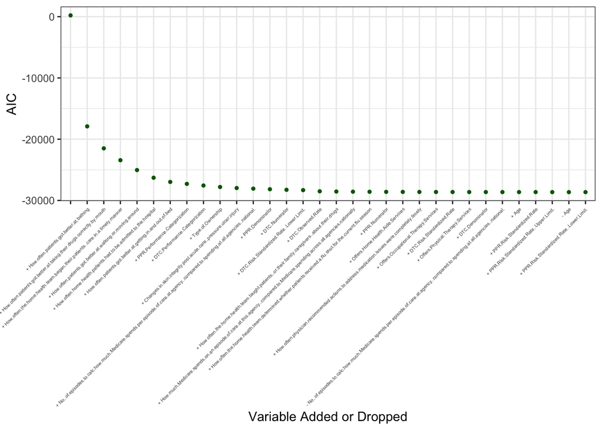

##### Summary

The third independent analysis examines how the influencing factors on home health agency quality rating have changed from 2015 to 2022. The analysis focuses on the data from 2015-2016 and 2021-2022. The primary objective is to identify changes in the factors that contribute significantly to the “Quality.of.Patient.Care.Star.Rating” over these two periods. By conducting stepwise regression, the study can identify the most influential factors for each time period. Understanding the variations in these factors can help healthcare administrators and policymakers target improvement efforts effectively, adapt policies, and address evolving challenges in home health care. For each time period (2015-2016 and 2021-2022), the data is imputed to handle any missing values. Stepwise regression models are then performed on the imputed data to conduct feature selection. The stepwise regression process identifies the most influential factors related to the “Quality.of.Patient.Care.Star.Rating” for each time period. The selected factors are ranked based on their contribution to the quality rating. By comparing the influential factors from 2015-2016 to 2021-2022, the analysis reveals any changes in the factors driving care quality over time. This information can guide stakeholders in devising targeted strategies to improve care quality and adapt to the evolving landscape of home health care.

The results shed the following insights gained from the stepwise regression model:

• Identifying important predictors: The model helps identify which variables have the most impact on the “Quality of Patient Care Star Rating.” Clients can focus on improving or addressing these significant predictors to enhance patient care quality. • Removing irrelevant variables: The model identifies variables that are less relevant to the outcome, which can save resources and simplify data collection efforts by focusing on the most critical variables. • Model interpretability: By selecting a parsimonious model, the stepwise regression makes the final model more interpretable, allowing clients to understand the factors affecting the outcome more easily. • Predictive power: A model with well-selected predictors tends to have better predictive power, meaning it can provide more accurate predictions for future cases.

Recommendations: